# Cyclist

zeynep

2023-08-08

## How Does a Bike-Share Navigate Speedy Success?

#### **ASK**

**Business Task** Objective of this analysis is to identify the differences between casual riders and annual members in order to gain insight on what draws the casual customers to buy an annual membership, and eventually present a marketing strategy towards them.

**Key Stakeholders**  
- Cyclist Executive Team : The notoriously detail-oriented executive team will decide whether to approve the recommended marketing program.

**Secondary Stakeholders**  
- Lily Moreno: The director of the marketing team and my manager.  
- Cyclist marketing analystics team: A team of data analysts who are responsible for collecting, analyzing and reporting data that helps guide Cyclist marketing strategy.  
- Cyclist customers

#### **PREPARE**

The [datasets](https://divvy-tripdata.s3.amazonaws.com/index.html) contain the previous 12 months of Cyclist trip data provided [Motivate International Inc.](https://motivateco.com/) licensed by Lyft Bikes and Scooters, in the form of csv files. The data sources seems to be fitting to ROCCC standards (Reliable and original, comprehensive and current, cited).

**Limitations**  
According to the privacy policy, the users are anonymized meaning using riders’ personally identifiable information is not available therefore i will not be able to connect pass purchases to credit card numbers to determine if casual riders live in the Cyclist service area or if they have purchased multiple single passes.

#### **PROCESS**

**Data Cleaning and Manipulation**  
For initial cleaning i unzipped 12 files and named them using appropriate naming conventions.Before processing them i stored the original data in the Google drive. For cleaning and manipulation of the data i used R since the datasets are large.

–>Combined all the data  
–>Cleaned N/A values  
–>Seperated date and time in the ‘started-at’ and ‘ended_at’ columns  
–>Turned to columns’ data types into their appropriate formats.(Dates as YYMMMDD and time are hours, minutes and seconds.)  
–>Calculated the ride duration by substracting the end_time from start_time. Since not all rides started and ended at the same day some duration values came out as negative and incorrect. So i only calculated duration for the same day rides. The number of the rows i did not include corresponds to 0.4 percent of my data.

–>Created a column named “day_of_the_week” to determine the weekday of the ride. “start_date” column is what determines day of the week which the ride occur.

#### **ANALYZE**

Even though the percentage might fluctuate throughout the year, annual members accounts for 60 percent of Cyclists total trips while casual riders accounts for ~40 percent.

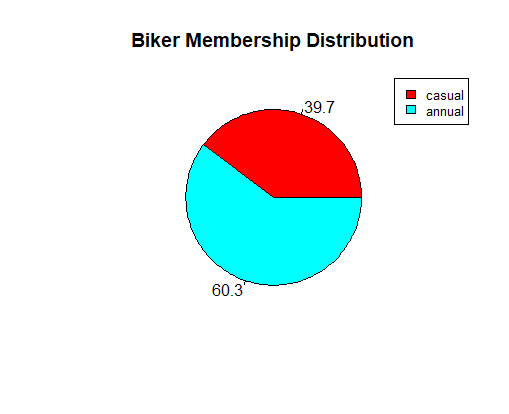

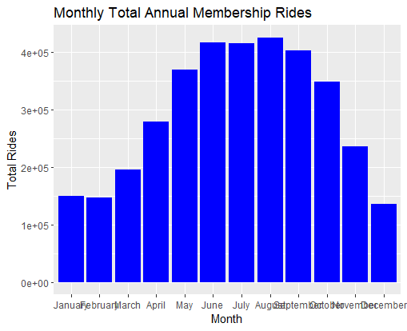

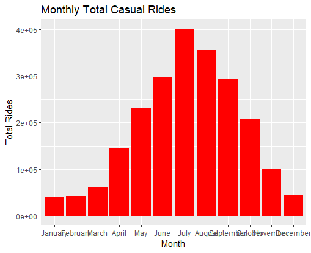

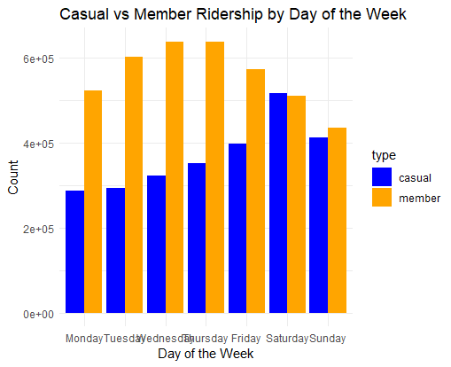

For the last 12 months, both casual number counts and annual memberships dropped compared to the previous year.

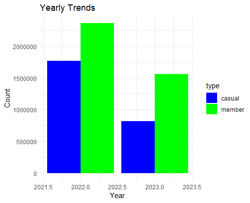

For both users, electric bikes are the most prefferred type of rideable while docked bikes are the least. Members’ preference between classic and electric bikes are close but casual riders prefer mostly electric bikes.

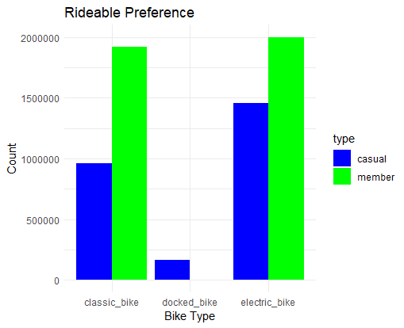

#### **SHARE**

[Tableau Dashboard Link](https://public.tableau.com/views/Cyclisticv2_16921403975020/Dashboard2?:language=en-US&:display_count=n&:origin=viz_share_link)

#### **ACT**

**Recommendations** –> Advertisements should be scheduled on Spring/Summer time. There could be discounts and special campaigns for targeted to casual riders in these seasons.  
–> Since the Cyclistic seems to be useful for day-to-day commute, the promotional campaings and adds can be placed on public transportations, as a way to show a peaceful alternative to busses, metros etc. Advertisements may show the Cyclistic as a way to escape traffic.  
–> Investing in electric/classic bikes instead of docked bikes since it seems to be more popular among all types of users.